# Nelson_12A

Riley Nelson

2022-11-30

Description: In this assignment, you will apply text mining techniques to evaluate tweets posted before, during, and after the landfall of Hurricane Harvey in the U.S. Hurricane Harvey made landfall as a category 4 storm in Texas on August 26, 2017. Classified as a major hurricane, Harvey brought massive amounts of rain to southeast Texas, resulting in widepsread and devastating flooding. Some tweets can provide useful, real-time information during natural disasters, but not all tweets provide helpful info.

## Part One

The Peak of Tweets

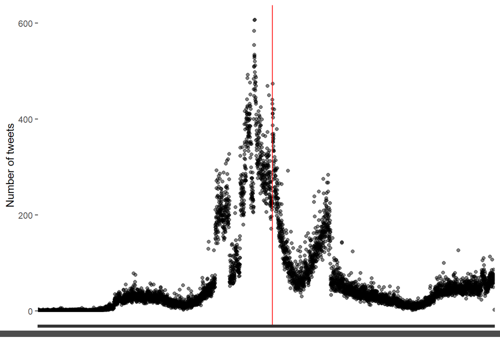

```r
harvey <- read.csv("data/hurricane_harvey_tweets.csv")

harvey %>%
  group_by(datetime) %>%
  summarize(ntweet = n()) -> harvey_sum



ggplot() +
  geom_point(data = harvey_sum, mapping = aes(x = datetime, y = ntweet), alpha = 0.5) +
  geom_vline(data = harvey_sum, mapping = aes(xintercept = "2017-08-26T03:00:00Z"), color = "red") +
  labs(x = " ", y = "Number of tweets")
```

## Part Two

Finding Common Words used in Tweets

```r
harvey %>%
  tibble(text = tweet) -> tweet

tweet %>%
  unnest_tokens(word,tweet) -> harvey_words

stop <- data("stop_words")



harvey_words %>%
  anti_join(stop_words, by = "word") -> harvey_text



harvey_text %>%
  select(word) %>%
  filter(!word %in% c('hurricane', 'harvey', 'hurricaneharvey','http', 'https', 'html', 'ift.tt', 'pic.twitter.com', 'twitter.com', 'fb.me', 'bit.ly', 'dlvr.it', 'youtube', 'youtu.be')) -> harvey_text



harvey_text %>%
  count(word) %>%
  top_n(20) -> num_word
```

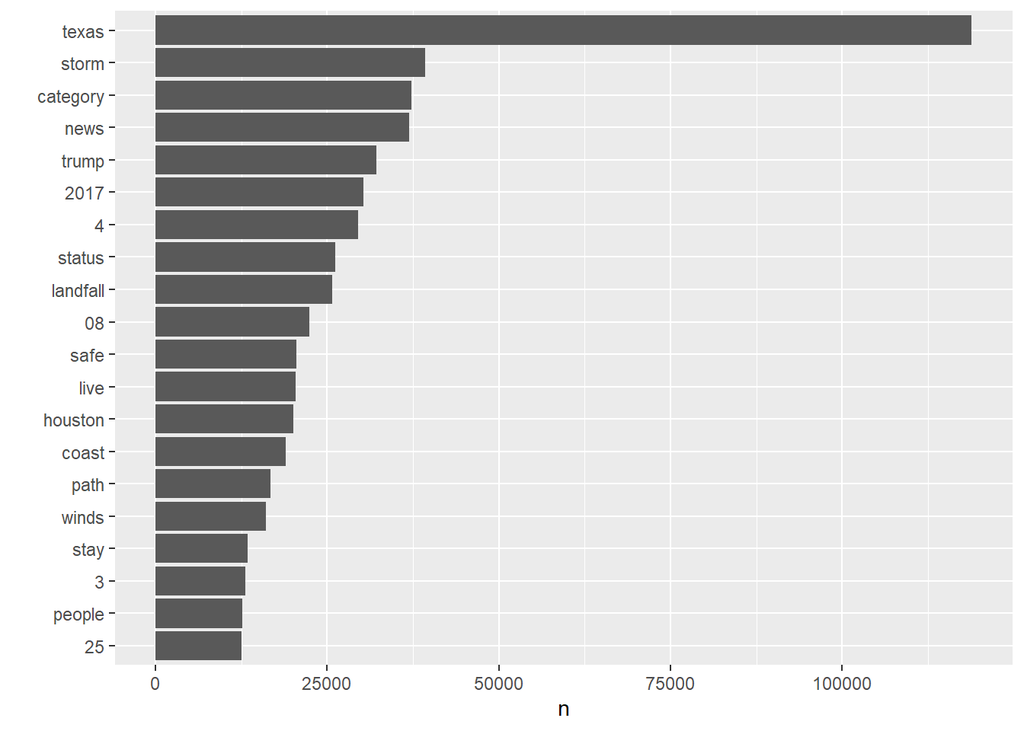

```r
vector <- c('25', 'people', '3','stay','winds', 'path', 'coast', 'houston', 'live', 'safe', '08', 'landfall', 'status' , '4' , '2017', 'trump', 'news', 'category', 'storm', 'texas')

ggplot() +
  geom_col(data = num_word, aes( x = word, y = n)) +
  scale_x_discrete(limits = vector) +
  coord_flip() +
  labs(x = " ")
```

## Part Three

Tweets that use the word refinery or refineries.

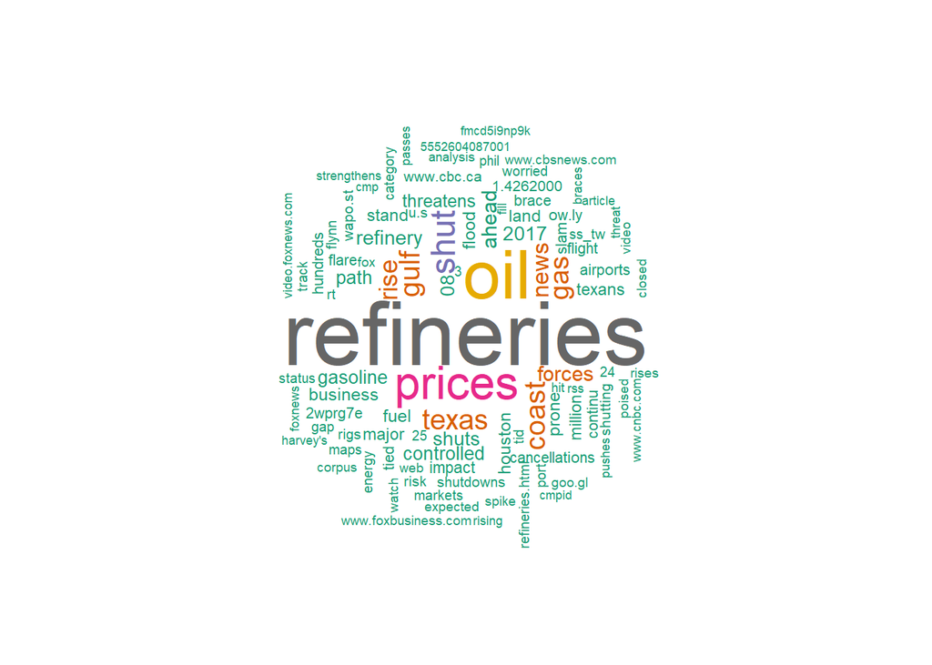

```r
harvey %>%
  filter(str_detect(tweet, "refinery | refineries")) -> refine

refine %>%
  tibble(text = tweet) -> refine_tweet

refine_tweet %>%
  unnest_tokens(word,tweet) -> refine_tokens

refine_tokens %>%
  anti_join(stop_words, by = "word") -> refine_tokens



refine_tokens %>%
  select(word) %>%
  filter(!word %in% c('hurricane', 'harvey', 'hurricaneharvey','http', 'https', 'html', 'ift.tt', 'pic.twitter.com', 'twitter.com', 'fb.me', 'bit.ly', 'dlvr.it', 'youtube', 'youtu.be')) -> refine_text

refine_text %>%
  count(word) -> refine_num



wordcloud <- wordcloud(words = refine_num$word, freq = refine_num$n, min.freq = 1,           max.words=100, random.order=FALSE, rot.per=0.35,            colors=brewer.pal(8, "Dark2"))
```

## Economic or Environmental?

Many of the tweets that included the words refinery or refineries are very economic focused. Some of the main words that were included the tweets were oil, prices, shut, gas, rise, and texas. From these words, one can infer that the people behind the tweets were focused on the rise of gas prices due to the hurricane.

## Part Four

Are the tweets postive or negative?

```r
harvey_text %>%
  count(word) -> harvey_count

afinn <- get_sentiments("afinn")

harvey_count %>%
  inner_join(afinn) -> afinn_join
harvey_words %>%
  anti_join(stop_words, by = "word") -> harvey_clean

harvey_clean %>%
  group_by(word) %>%
  filter(!word %in% c('hurricane', 'harvey', 'hurricaneharvey','http', 'https', 'html', 'ift.tt', 'pic.twitter.com', 'twitter.com', 'fb.me', 'bit.ly', 'dlvr.it', 'youtube', 'youtu.be')) %>%
  ungroup(word) -> harvey_clean


afinn_join %>%
  inner_join(harvey_clean) -> afinn_com
```

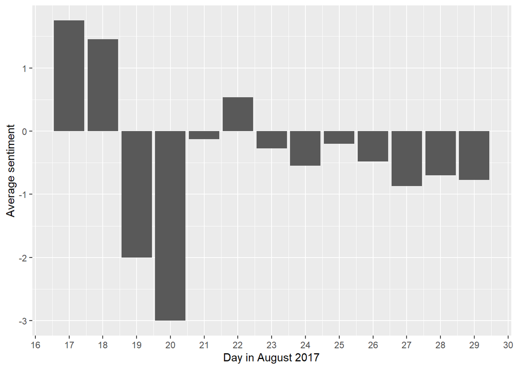

```r
afinn_com %>%
  mutate(date_col = date) %>%
  group_by(date_col) %>%
  summarize(value = mean(value)) -> affin_sum

affin_sum$date_col <- as.Date(affin_sum$date_col , format = "%Y-%m-%d")

ggplot() +
  geom_col(data = affin_sum, aes( x = date_col, y   = value)) +
  scale_x_date(date_breaks = "day", date_labels = "%d") +
  labs(x = "Day in August 2017", y = "Average sentiment")
```